# Class_project_clusterProfiler

SZ

4/12/2020

## Enrichment analysis is a statistical method that determines whether genes from pre-defined sets (ex: those beloging to a specific GO term or KEGG pathway) are present more than would be expected in our dataset. To accompkish this goal, a common way is to incorporate the biological knowledge, such as Gene Ontology (GO) and Kyoto Encyclopedia of Genes and Genomes (KEGG).

## Here we use clusterProfiler to perform Gene Ontology over-representation analysis and KEGG GSEA analysis. clusterProfiler implements methods to analyze, compare, and visualize functional profiles of genes and gene clusters.

```r
## load required packages
setwd("~/SYBB412_class_project")

suppressPackageStartupMessages(library(clusterProfiler))
suppressPackageStartupMessages(library(org.Hs.eg.db))
suppressPackageStartupMessages(library(tidyverse))
```

## Import our dataset and format to meet the requirment to be used in clusterProfiler

```r
## We firstly need to creat a database from org.Hs.eg.db
database <- org.Hs.eg.db

## we then read the significantly differentially expressed genes table and extract columns of gene symbol, ensembl id, and entrez id
DEG_sig <- read.table("DESeq2_DEG_Sig_symbol_ensembl.tab", header = TRUE)

gene_list <- DEG_sig[, 3]

ensembl <- as.character(DEG_sig$ensemblid)

ids <- bitr(ensembl,
            fromType = "ENSEMBL",
            toType = c("ENTREZID","SYMBOL"),
            OrgDb = database)
```

## Perform GO over-representation (enrichment) analysis

```r
ego <- enrichGO(gene = ids[,1], ## We use ensembl id
                OrgDb = database,
                ont = "BP", ## We specify BP (Biological Process)
                keyType = "ENSEMBL",
                pAdjustMethod = "BH",
                minGSSize = 10,
                maxGSSize = 500,
                pvalueCutoff = 0.05,
                pool = FALSE,
                readable = TRUE)

## Use head function to check the result
head(ego[, 1:8])
```

```
##                    ID                          Description GeneRatio   BgRatio
## GO:0042744 GO:0042744  hydrogen peroxide catabolic process   18/1909  33/20610
## GO:0015671 GO:0015671                     oxygen transport   12/1909  15/20610
## GO:0019730 GO:0019730       antimicrobial humoral response   40/1909 148/20610
## GO:0015669 GO:0015669                        gas transport   13/1909  19/20610
## GO:0043062 GO:0043062 extracellular structure organization   86/1909 474/20610
## GO:0006959 GO:0006959              humoral immune response   66/1909 327/20610
##                  pvalue     p.adjust       qvalue
## GO:0042744 6.213365e-11 3.580762e-07 3.157697e-07
## GO:0015671 1.347102e-10 3.881675e-07 3.423057e-07
## GO:0019730 3.407204e-10 6.545240e-07 5.771924e-07
## GO:0015669 5.652512e-10 8.143857e-07 7.181665e-07
## GO:0043062 8.987055e-10 9.711936e-07 8.564477e-07
## GO:0006959 1.011133e-09 9.711936e-07 8.564477e-07
##                                                                                                                                                                                                                                                                                                          …
## GO:0042744                                                                                                                                                                                                                                                                                               …
## GO:0015671                                                                                                                                                                                                                                                                                               …
## GO:0019730                                                                                                                                                                                                                                                                                               …
## GO:0015669                                                                                                                                                                                                                                                                                               …
## GO:0043062 PLOD1/MMP8/MPO/TGFBI/MMP14/COL11A1/COL10A1/COL17A1/ELANE/CDH…
## GO:0006959                                                                                                                                                                LCN2/S100A8/BPI/LTF/S100A12/CAMP/DEFA4/MS4A1/ELANE/S100A9/PR…
```

## clusterProfiler has quite a few ways to visualize the over-represented GO terms. Here We explore the barplot, dotplot, and enrichment plot.

## The barplot and dotplot shows the number of genes associated with the first, for example, 10 terms (bar length or dot size) and the p-adjusted values for these terms (color). The categroyplot shows the connection between different terms and genes associated with each term.

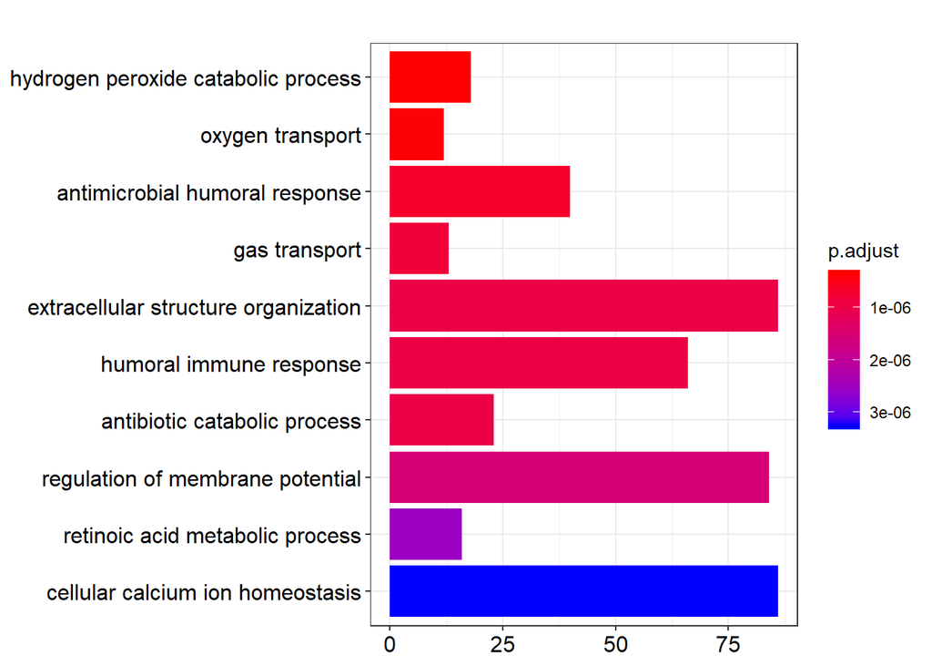

```r
barplot(ego, showCategory = 10)
```

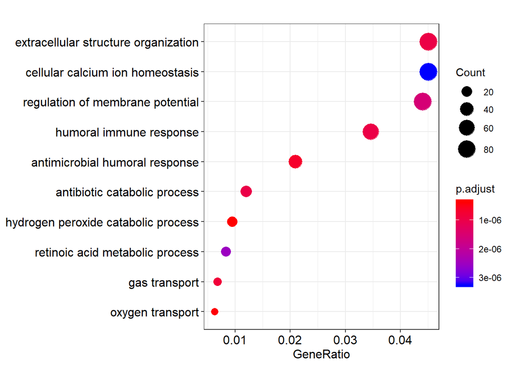

```r
dotplot(ego, showCategory = 10)
```

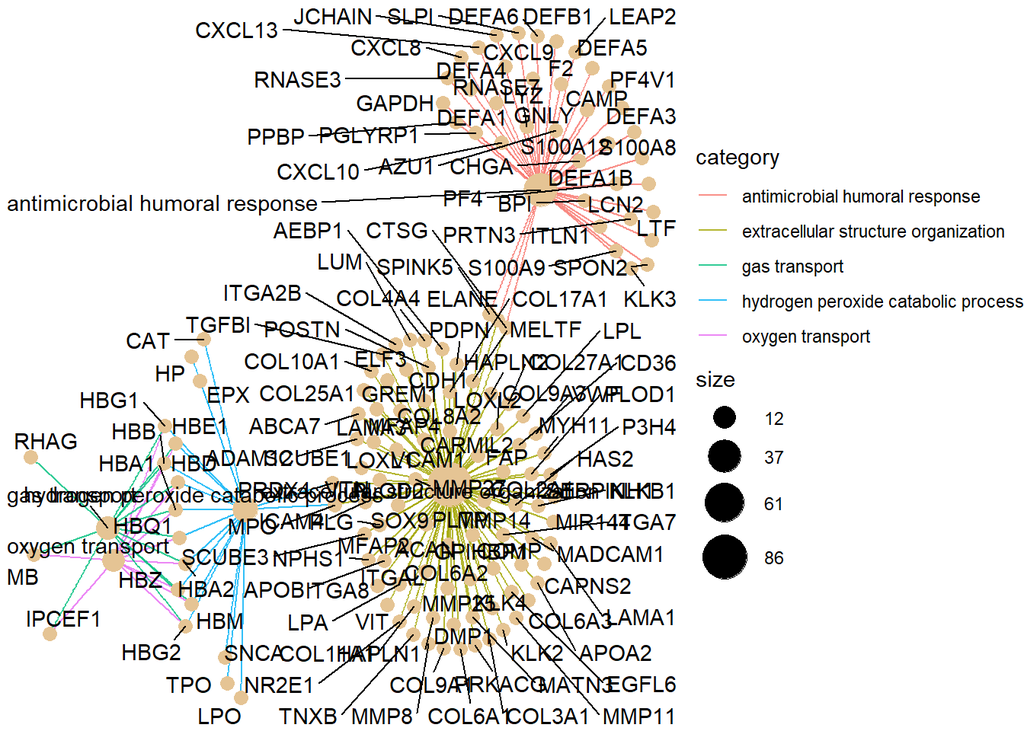

```r
cnetplot(ego, showCategory = 5, foldChange = gene_list, colorEdge = TRUE)
```

## Enrichment map organizes enriched terms into a network with edges connecting overlapping gene sets. In this way, mutually overlapping gene sets are tend to cluster together, making it easy to identify functional modules.

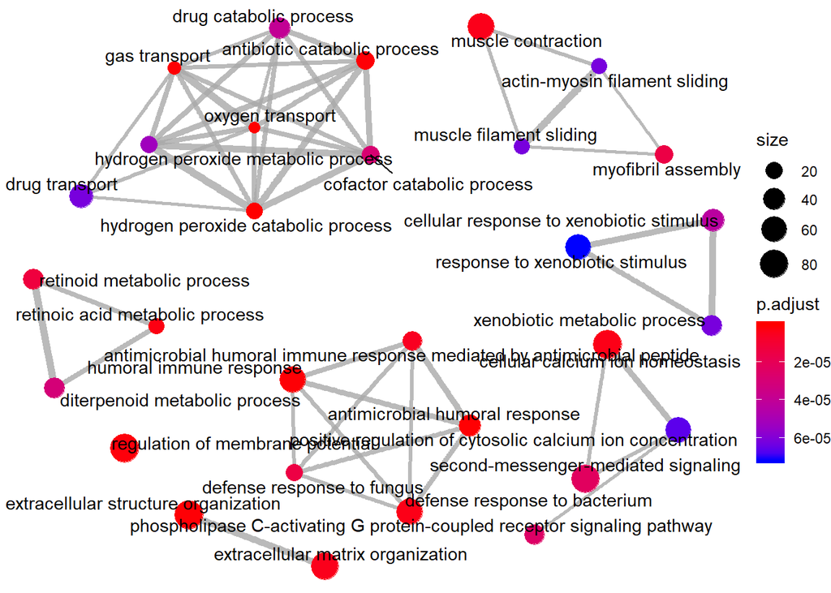

```r
emapplot(ego, showCategory = 30)
```

```r
## write the go enrichment result to a table and save the file
GO_summary <- as.data.frame(ego)
write.table(GO_summary, "GO_summary")
```

## We can also use clusterProfiler to perform GSEA analysis. To perform GSEA analysis of KEGG gene sets, clusterProfiler requires the genes to be identified using Entrez IDs for all genes in our results dataset. We also need to remove the NA values and duplicates (due to gene ID conversion) prior to the analysis

```r
## Firstly, we need to create a gene rank list. Read the table of all differentially expressed genes
DEG <- read.table("DESeq2_DEG_all.tab", header = TRUE)

## extract the "stat" and "gene_id" columns from DEG and give it a new name of gene_id

gene_id <- DEG[,c(4,7)]

## Remove NA or duplicated vaule for entrezid if there was any
entrez <- filter(gene_id, geneid != "NA")
entrez <- entrez[which(duplicated(gene_id$geneid) == F), ]

## Creat the rank list
rank_list <- entrez$stat
names(rank_list) <- entrez$geneid
rank_list <- sort(rank_list, decreasing = TRUE)

## Check to make sure there is no NA in the list, and it returns FALSE, which is satisfactory.
all(is.na(rank_list))
```

```
## [1] FALSE
```

## Perform GSEA KEGG analysis

```r
gseaKEGG <- gseKEGG(rank_list,
                    organism = "hsa",
                    keyType = "kegg",
                    pAdjustMethod = "BH",
                    minGSSize = 10,
                    maxGSSize = 500,
                    pvalueCutoff = 0.05,
                    use_internal_data = FALSE)
```

```
## preparing geneSet collections...
```

```
## GSEA analysis...
```

```
## leading edge analysis...
```

```
## done...
```

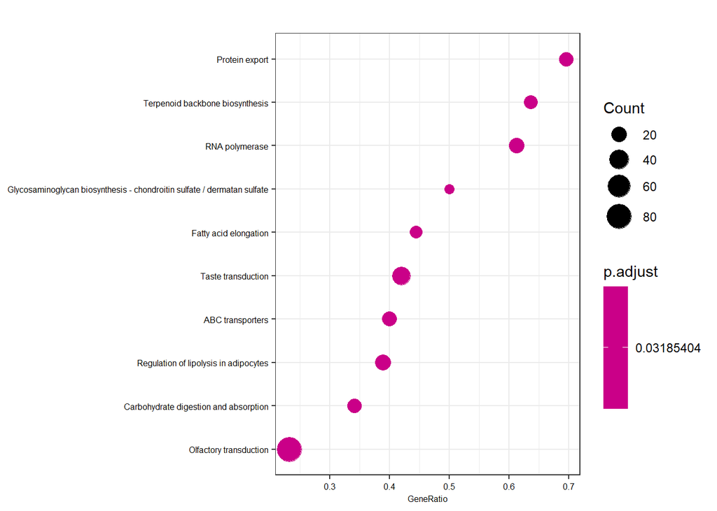

```r
gseaKEGG_summary <- as.data.frame(gseaKEGG)
gseaKEGG_summary <- gseaKEGG_summary[order(gseaKEGG[,4], decreasing = TRUE),]

## Save the GSEA KEGG analysis result as a table
write.table(gseaKEGG_summary, "gseaKEGG_summary")

## Again, we can plot dotplot
dotplot(gseaKEGG, showCategory = 10, font.size = 6)
```

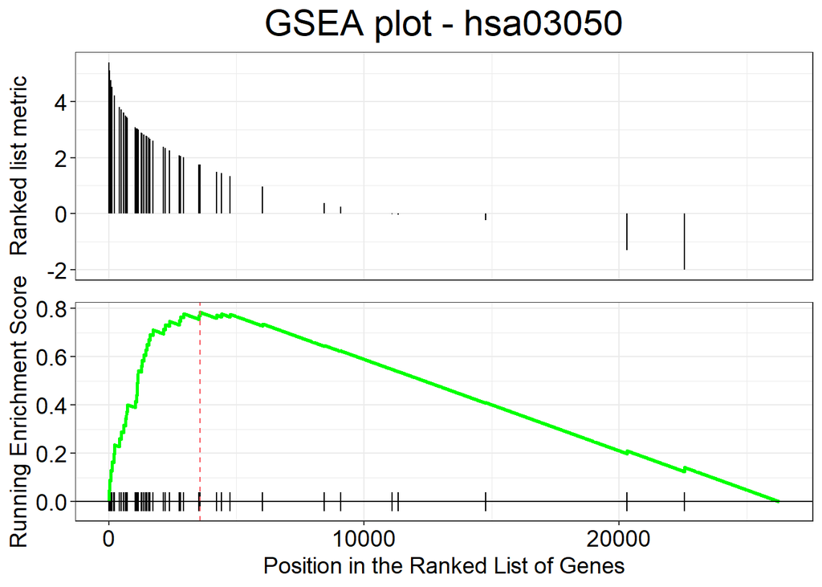

```r
## We can plot the GSEA plot for a single enriched pathway, for example, `hsa03050`, which has the highest enrichment score.
gseaplot(gseaKEGG, geneSetID = 'hsa03050', title = "GSEA plot - hsa03050")
```